# 615 Final

Zhaosheng-Xie

2020/12/11

# Introduction

This is 615 final project. I use data from adzuna to find out which is the main category of job that data scientists do. Why is this question? Because when finishing master degree, I will find a job as a data scientist in different field. Personally speaking, I look forward to entering a big IT company.

# Get data from Adzuna

This is a data sample. This dataset contains several columns and 3 small datasets.  
Here is the api link: https://developer.adzuna.com/activedocs#!/adzuna/search  
When you have appid and app_key, you can set some parameters and click “try it out”. Data is in Response body.

```r
# Some apis of adzuna
# appid = 8eb483ae
# app_key = 003603843368e6c4eaee2a744120d7e8

# appid = f0c87e31
# app_key = 84f049d50dd8aa26e2e48aff8ba0e61f

# adzuna data sample
data <- fromJSON("https://api.adzuna.com/v1/api/jobs/us/search/1?app_id=8eb483ae&app_key=003603843368e6c4eaee2a744120d7e8&results_per_page=50&what_phrase=data&what_or=data%20scientce%20statistician&title_only=data%20scientist")
adzuna_sample <- data$results
adzuna_sample <-  adzuna_sample %>%
  select("id","title","description","latitude","longitude","created","salary_is_predicted") %>%    mutate("company_name"=data$results$company$display_name) %>%  # choose some columns
    mutate("category_label"=data$results$category$label) %>%
mutate("location"=data$results$location$display_name)
# write.table(adzuna_sample,"D:/MSSP/Rdata/615/615 final/adzuna_sample.csv",col.names = TRUE,row.name = FALSE,sep = ",")
```

Because this site only allows us to get 1 page of data at a time (50 observations), I write a loop to obtain 10 pages data.

```r
# https://api.adzuna.com/v1/api/jobs/us/search/1?app_id=f0c87e31&app_key=84f049d50dd8aa26e2e48aff8ba0e61f&results_per_page=50&what_phrase=data&what_or=data%20scientce%20statistician

# use loop to get 10 pages data

us <- list(NULL)  # choose data of USA
length(us) <- 10   # set page number
for (i in 1:length(us)) {
  url <- paste("https://api.adzuna.com/v1/api/jobs/us/search/",i,"?app_id=f0c87e31&app_key=84f049d50dd8aa26e2e48aff8ba0e61f&results_per_page=50&what_phrase=data&what_or=data%20scientce%20statistician",sep = "")
  test <- fromJSON(url)
  us[[i]] <- test$results %>% # obtain data
    select("id","title","description","latitude","longitude","created","salary_is_predicted") %>%    mutate("company_name"=test$results$company$display_name) %>%  # choose some columns
    mutate("category_label"=test$results$category$label) %>%
mutate("location"=test$results$location$display_name)
}
US <- do.call(rbind, us) # use rbind() to join 10 small datasets
US <- as.data.frame(US)
# save(US,file = "US.RData")
# write.table(US,"D:/MSSP/Rdata/615/615 final/US.csv",col.names = TRUE,row.name = FALSE,sep = ",")
```

# Data cleaning

```r
# Check na
length(which(!is.na(US)=="FALSE"))
```

```
## [1] 58
```

```r
DS <- US
DS <- na.omit(DS)
length(which(!is.na(DS)=="FALSE"))
```

```
## [1] 0
```

```r
# remove unneeded columns
unique(DS$salary_is_predicted)
```

```
## [1] "0"
```

```r
DS <- dplyr::select(DS,-"salary_is_predicted")

# Separate "created" into "date" and "time"
DS1 <- DS
DS1 %<>% separate(col = created, into = c("date","time"), sep = "T", remove = TRUE)
DS1 %<>% separate(col = time, into = c("time","z"), sep = "Z", remove = TRUE)
DS1 <- select(DS1,-"z")

# Separate "location" into "city" and "county_state"
DS2 <- DS1
DS2 %<>% separate(col = location, into = c("city","county_state"), sep = ",", remove = TRUE)
# title
DS3 <- DS2
DS3$title <- gsub('</strong>','',DS3$title)
DS3$title <- gsub('<strong>','',DS3$title)

# description
DS4 <- DS3
DS4$description <- gsub('</strong>','',DS4$description)
DS4$description <- gsub('<strong>','',DS4$description)

# write.table(DS4,"D:/MSSP/Rdata/615/615 final/shiny/DS4.csv",col.names = TRUE,row.name = FALSE,sep = ",")
# save(DS4,file = "DS4.RData")
```

# EDA

```r
### This chuck is to get word frequency in title and description

# define a function to show top frequency
top.freq <- function(x,topn=0){
  require(plyr)
  top.df <- count(x)
  top.df <- top.df[order(top.df$freq,decreasing = TRUE),]
  if(topn > 0) return(top.df[1:topn,])
  else  return(top.df)
}

## description data

# extract data from DS4
description <- DS4$description
# use jieba
engine <- worker(user = "user.dict.utf8",encoding = 'UTF-8')
# get rid of irrelevant words
word.lis.des <- lapply(description, function(x){
  v <- gsub('[\u4e00-\u9fa5|0-9|\\.|...]','',segment(x,engine))
  v <- v[v!='']
  return(v)
})
# to capital
segWord.des <- toupper(unlist(word.lis.des))
# load stopwords
stopWords <- toupper(readLines("stop_words.utf8",encoding = 'UTF-8'))

# get word frequency in description
removewords <- function(targetword,stopword){
  targetword = targetword[targetword%in%stopword == F]
  return(targetword)
}

segword.des <- sapply(X=segWord.des, FUN = removewords,stopWords)

word_freq.des <- top.freq(unlist(segword.des),500)
# write.table(word_freq.des,"D:/MSSP/Rdata/615/615 final/shiny/word_freq.des.csv",col.names = TRUE,row.name = FALSE,sep = ",")
word_freq.des
```

```
##                     x freq
## 527              DATA 1325
## 2143             TEAM  180
## 751             ENTRY  159
## 282          BUSINESS  154
## 728          ENGINEER  138
## 395           COMPANY  108
## 2369             WORK  108
## 1418              NEW  103
## 1874                S   88
## 1269             MAKE   87
## 102         ANALYTICS   83
## 1158              JOB   80
## 1250          LOOKING   80
## 803        EXPERIENCE   78
```

[output cut: 486 more lines]

```r
## title data

# extract data from DS4
title <- DS4$title
# get rid of irrelevant words
word.lis.tit <- lapply(title, function(x){
  v <- gsub('[\u4e00-\u9fa5|0-9|\\.|...]','',segment(x,engine))
  v <- v[v!='']
  return(v)
})
# to capital
segWord.tit <- toupper(unlist(word.lis.tit))

# get word frequency in description
segword.tit <- sapply(X=segWord.tit, FUN = removewords,stopWords)

word_freq.tit <- top.freq(unlist(segword.tit),149)
# write.table(word_freq.tit,"D:/MSSP/Rdata/615/615 final/shiny/word_freq.tit.csv",col.names = TRUE,row.name = FALSE,sep = ",")
word_freq.tit
```

```
##                   x freq
## 31             DATA  499
## 41         ENGINEER  137
## 44            ENTRY  105
## 124       SCIENTIST   66
## 96         PHARMACY   59
## 126          SENIOR   47
## 6           ANALYST   45
## 137    STATISTICIAN   42
## 146      TECHNICIAN   38
## 92        OVERNIGHT   27
## 37         DIRECTOR   21
## 42      ENGINEERING   18
## 128           SHIFT   18
## 9         ARCHITECT   17
```

[output cut: 135 more lines]

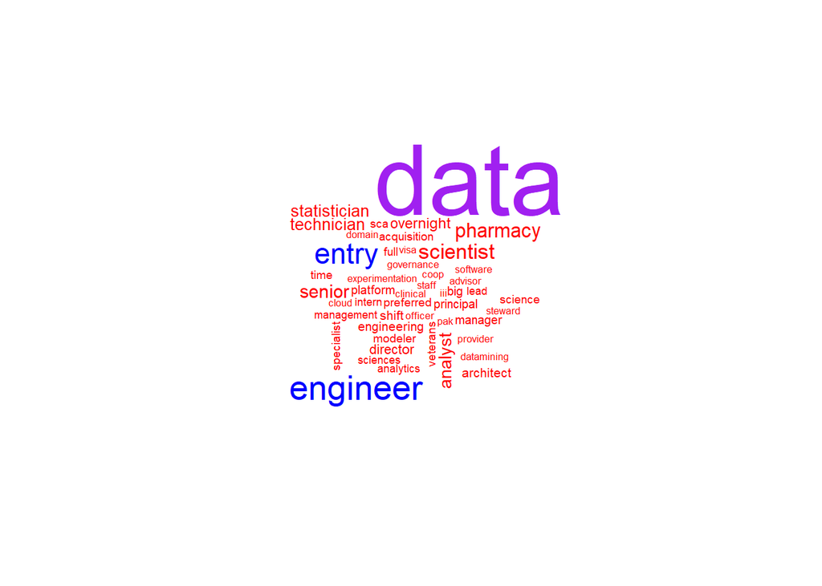

```r
# word cloud of title

title.cloud1 <- wordcloud(word=DS4$title,scale=c(5,0.5),
          colors=c('red','blue','green','yellow','purple'),random.color=F,random.order=T)
```

```r
title.cloud2 <- wordcloud2(data=word_freq.tit,shape = "circle",size = 1)
title.cloud2
```

[interactive chart not shown]

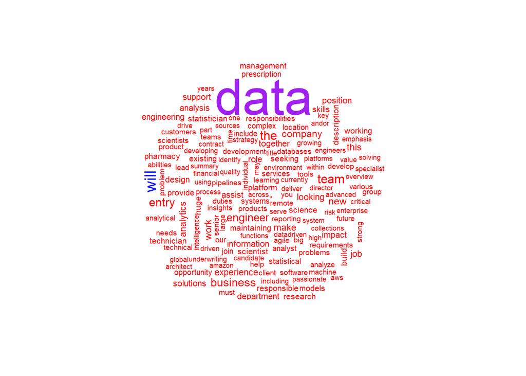

```r
# htmlwidgets::saveWidget(title.cloud2, file ="title.cloud2.html",selfcontained = FALSE)
# word cloud of description

description.cloud1 <- wordcloud(word=DS4$description,min.freq=20,
          colors=c('red','blue','green','yellow','purple'), random.color=F)
```

```r
description.cloud2 <- wordcloud2(data=word_freq.des,shape = "diamond")
description.cloud2
```

[interactive chart not shown]

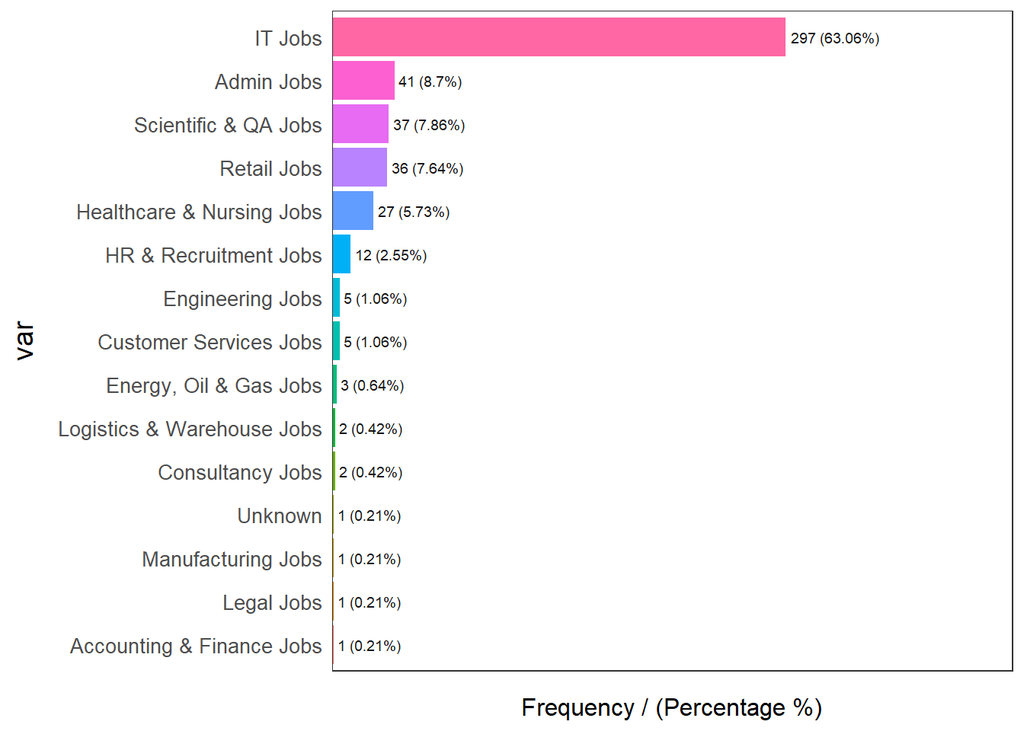

```
##                           var frequency percentage cumulative_perc
## 1                     IT Jobs       297      63.06           63.06
## 2                  Admin Jobs        41       8.70           71.76
## 3        Scientific & QA Jobs        37       7.86           79.62
## 4                 Retail Jobs        36       7.64           87.26
## 5   Healthcare & Nursing Jobs        27       5.73           92.99
## 6       HR & Recruitment Jobs        12       2.55           95.54
## 7      Customer Services Jobs         5       1.06           96.60
## 8            Engineering Jobs         5       1.06           97.66
## 9      Energy, Oil & Gas Jobs         3       0.64           98.30
## 10           Consultancy Jobs         2       0.42           98.72
## 11 Logistics & Warehouse Jobs         2       0.42           99.14
## 12  Accounting & Finance Jobs         1       0.21           99.35
## 13                 Legal Jobs         1       0.21           99.56
## 14         Manufacturing Jobs         1       0.21           99.77
## 15                    Unknown         1       0.21          100.00
```

```r
# htmlwidgets::saveWidget(description.cloud2, file ="description.cloud2.html",selfcontained = FALSE)


# frequency of category_label
funModeling::freq(DS4$category_label)
```

From the category proportion histogram, I can draw a conclusion that most of the jobs associated with data scientists are of the IT category label.

## Map

```r
# map data
tmap_mode('view')
```

```
## tmap mode set to interactive viewing
```

```r
epsg_wgs84 <- 4326 # GPS CRS (WGS 84)
category <-
  DS4 %>%
  st_as_sf(coords = c("longitude", "latitude")) %>%
  st_set_crs(epsg_wgs84)
category_plot<- category %>% select(id, title, company_name, category_label,date, geometry)
# save(category_plot,file="shiny/category_plot.RData")
```

```r
# plot
category_map <-
  tm_shape(category_plot) +
  tm_dots(col = 'category_label', size = .02, alpha=.5,title='Category label')
category_map
```

[interactive chart not shown]

From this map, data scientists mainly work on the eastern and western seaboard of the United States. Part of them work in the Great Lakes region and Texas.